# 20180316_复习R语言聚类2

wzy

2018年3月16日

```r
library(cluster)
library(mclust)
```

# 《数据挖掘：R语言实战》第7章

## 7.1 概述

- K-均值聚类（K-Means）
- K-中心店聚类（K-Medoids）
- 密度聚类（Densit-based Spatial Clustering of Application with Noise, DBSCAN）
- 系谱聚类（Hierarchical Clustering, HC）
- 期望最大化聚类（Expectation Maximization, EM）

这些算法本身无优劣，二最终运用于数据的效果存在好坏差异，这取决于数据使用者对于算法的选择是否恰当。

### 7.1.1 K-均值聚类

快速聚类方法，但对异常值或极端值敏感，稳定性差，因此较适合分布集中的大样本数据集。

### 7.1.2 K-中心点聚类

是针对K-均值算法易受极值影响这一缺点的改进算法。

在原理上的差异在于选择各类别中心点时**不取样本均值点**，而在类别内选取**到其余样本距离之和最小的样本**为中心点。

### 7.1.3 系谱聚类（层次聚类）

不需事先设定类别数k，每次迭代过程仅将距离最近的两个样本/簇聚为一类

### 7.1.4 密度聚类

DBSCAN是基于密度的聚类方法中最常用的代表算法之一，另外还有OPTICS算法，DENCLUE算法。

K-均值，K-中心点，系谱聚类这些基于距离的聚类算法，其优势在于弥补了它们只能发现“类圆形”聚类簇的缺陷，该类算法由于是基于“密度”来聚类的，可以再具有噪声的空间数据库中发现任意形状的簇。

DBSCAN算法将簇看做是空间数据中被低密度区域分隔开的“稠密区域”，即密度相连样本点的最大集合。

### 7.1.5 期望最大化聚类（EM算法）

它将数据集看做一个含有隐形变量的概率模型，并以实现模型最优化，即获取与数据本身性质最契合的聚类方式为目的，通过“反复估计”模型参数找出最优解，同时给出相应的最优类别数k。

而“反复估计”过程即是EM算法的精华所在，这一过程由E-step(Expectation)和M-step(Maximization)两个步骤较低进行来实现。

## 7.2 R中的实现

### 7.2.1 相关软件包

- stats 包含基本统计函数，如用于统计计算和随机数生成等
- kmeans() K-均值
- hclust()/cutree()/rect.hclust() 系谱聚类
- cluster 用于聚类分析，含有很多聚类相关的函数及数据集
- pam() K-中心点
- fpc 含有若干聚类算法函数，如固定点聚类、线性回归聚类、DBSCAN聚类等
- dbscan() 密度聚类
- mclust 用于处理基于高斯混合模型，通过EM算法实现的聚类、分类以及密度估计等问题
- Mclust()/clustBIC()/mclust2Dplot()/densityMclust() 期望最大化聚类

### 7.2.2 核心函数

#### kmeans

kmeans(x,centers,iter.max=10,nstart=1,algorithm=c(“Hartigan-Wong”,“Lloyd”,“For-gy”,“MacQueen”))

- x为数据集
- centers为预设类别k
- iter.max为迭代的最大值，默认为10
- algorithm提供了4种算法选择

#### pam

pam(x,k,diss=inherits(x,“dist”),metric=“euclidean”,medoids=NULL,stand=FALSE,cluster.only=FALSE)

- x 待处理数据
- k 类别数
- metric 用于选择样本点间距离测算的方式，可供选择的由euclidean与manhattan
- medoids 取NULL由软件选择初始样本点
- cluster.only 用于选择是否仅获取样本所归属的类别这一聚类结果，若选择TRUE则聚类效率更高
- keep.data 选择是否在聚类结果中保留数据集

#### dbscan

dbscan(data,eps,MinPts=5,scale=F,method=c(“hybrid”,“raw”,“dist”),seeds=T,showplot=F,countmode=NULL)

- data 为待聚类数据集
- eps 为考察每一样本点是否满足密度要求时，所划定考察领域的半径
- MinPts 密度阈值，当考察点eps领域内的样本点数大于等于MinPts时，该点才被认为是核心对象，否则为边缘点
- scale 用于选择是否在聚类前先对数据进行标准化
- method 如何看待data
- hybrid 表示data为距离矩阵
- raw 表示data为原始数据集，且不计算其距离矩阵
- dist 也将data视为原始数据集，但计算局部聚类矩阵
- showplot 选择是否输出聚类结果示意图
- 0 不绘图
- 1 每次迭代绘图
- 2 仅对子迭代绘图

#### hclust/cutree/rect.hclust

hclust(d,method=“complete”,members=NULL)

- d为待处理数据集样本间的距离矩阵，可用dist()函数计算得到
- method 拥有聚类方法选择ward/single/complete
- members 用于指出每个待聚类样本点是由几个单样本构成

cutree(tree,k=NULL,h=NULL) 用于对hclust()函数的聚类结果进行剪枝，选择输出制定类别数的系谱聚类结果

- tree 为hclust()的聚类结果
- k/h 用于控制选择输出的结果

rect.hclust()可以在plot()形成的系谱图中将制定类别中的样本分支用方框表示出来，十分有助于直观分析聚类结果。

rect.hclust(tree,k=NULL,which=NULL,x=NULL,h=NULL,border=2,cluster=NULL)

#### Mclust/mclustBIC/mclust2Dplot/densityMclust 函数

源于mclust软件包，Mclust()函数为进行EM聚类的核心函数

Mclust(data,G=NULL,modelNames=NULL,prior=NULL,control=emControl(),initialization=NULL,warn=FALSE,…)

mclustBIC()函数的参数设置与Mclust基本一致，用于获取数据集所对应的参数化高斯混合模型的BIC值，评价模型优劣，BIC值越高模型越优。

mclust2Dplot()可根据EM算法所生成的参数对二维数据制图。

densityMclust()函数利用Mclust()的聚类结果对数据集中的每个样本点进行密度估计。

### 7.2.3 数据集

```r
countries <- read.csv("D:\\data\\contries.csv",header = F)
names(countries) <- c("country","birth","death")
countries <- countries[countries$country!="FRANCE",]
```

```r
var <- countries$country
var <- as.character(var)
for(i in 1:68)
  row.names(countries)[i]=var[i]
```

## 7.3 应用案例

### 7.3.1 K-均值聚类

```r
fit_km1 <- kmeans(countries[,-1],center=3)
print(fit_km1)
```

```
## K-means clustering with 3 clusters of sizes 27, 2, 39
##
## Cluster means:
##      birth     death
## 1 40.50741 10.811111
## 2 55.95000 29.350000
## 3 20.19231  9.120513
##
## Clustering vector:
##        ALGERIA          CONGO          EGYPT          GHANA    IVORY COAST
##              1              1              1              2              2
##       MALAGASY        MOROCCO        TUNISIA       CAMBODIA         CEYLON
##              1              1              1              1              1
##          CHINA         TAIWAN      HONG KONG          INDIA      INDONESIA
##              1              1              1              3              3
##           IRAQ          JAPAN         JORDAN          KOREA       MALAYSIA
##              3              3              1              3              1
##       MONGOLIA   PHILLLIPINES          SYRIA       THAILAND        VIETNAM
##              1              3              3              1              3
##         CANADA     COSTA RICA    DOMINICAN R      GUATEMALA       HONDURAS
##              3              1              1              1              1
##         MEXICO      NICARAGUA         PANAMA  UNITED STATES      ARGENTINA
##              1              1              1              3              3
##        BOLIVIA         BRAZIL          CHILE       COLOMBIA        ECUADOR
##              3              1              1              1              1
##           PERU        URUGUAY      VENEZUELA        AUSTRIA        BElGIUM
##              3              3              1              3              3
##        BRITAIN       BULGARIA CZECHOSLOVAKIA        DENMARK        FINLAND
##              3              3              3              3              3
##      E.GERMANY      W.GERMANY         GREECE        HUNGARY        IRELAND
##              3              3              3              3              3
##          ITALY    NETHERLANDS         NORWAY         POLAND       PORTUGAL
##              3              3              3              3              3
##        ROMANIA          SPAIN         SWEDEN    SWITZERLAND       U.S.S.R.
##              3              3              3              3              3
##     YUGOSLAVIA      AUSTRALIA    NEW ZEALAND
##              3              3              3
##
## Within cluster sum of squares by cluster:
## [1] 1115.8652   28.1700  841.4513
##  (between_SS / total_SS =  81.6 %)
##
## Available components:
##
## [1] "cluster"      "centers"      "totss"        "withinss"
## [5] "tot.withinss" "betweenss"    "size"         "iter"
## [9] "ifault"
```

```r
fit_km1$totss
```

```
## [1] 10818.94
```

```r
fit_km1$tot.withinss
```

```
## [1] 1985.486
```

```r
fit_km1$betweenss
```

```
## [1] 8833.454
```

调节类别数参数center的取值，并通过前面所讨论的组间平方和占总平方和的百分比值（简称为“聚类优度”）来比较选择出最优类别数。

有68个样本，类别数从1~67取遍

```r
result=rep(0,67)
for(k in 1:67){
  fit_km <- kmeans(countries[,-1],center=k)
  result[k] <- fit_km$betweenss/fit_km$totss
}
round(result,2)
```

```
##  [1] 0.00 0.72 0.81 0.85 0.91 0.92 0.94 0.93 0.96 0.94 0.96 0.95 0.97 0.97
## [15] 0.97 0.95 0.98 0.98 0.98 0.98 0.98 0.98 0.98 0.99 0.99 0.99 0.99 0.99
## [29] 0.99 0.99 0.99 0.99 0.99 0.99 0.99 1.00 0.99 1.00 0.99 0.99 1.00 0.99
## [43] 1.00 1.00 1.00 1.00 0.99 1.00 1.00 1.00 1.00 1.00 1.00 1.00 1.00 1.00
## [57] 1.00 1.00 1.00 1.00 1.00 1.00 1.00 1.00 1.00 1.00 1.00
```

在类别数小于10时，随着类别数增加聚类效果越来越好；类别数超过10后，聚类效果基本不再提高

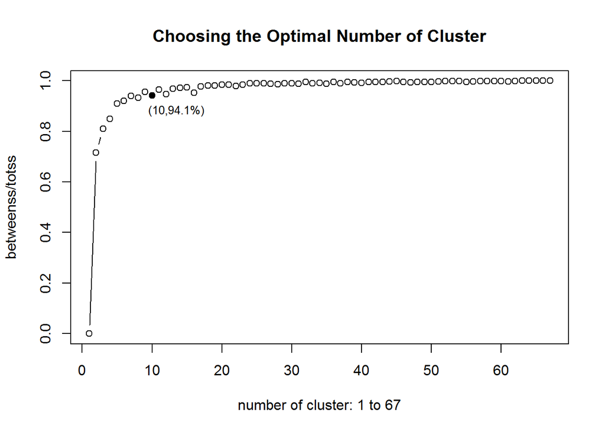

```r
plot(1:67,result,type="b",main="Choosing the Optimal Number of Cluster",
     xlab="number of cluster: 1 to 67",ylab="betweenss/totss")
points(10,result[10],pch=16)
legend(10,result[10],paste("(10,",sprintf("%.1f%%",result[10]*100),")",sep=""),bty="n",xjust=0.3,cex=0.8)
```

如果并非要求极高的聚类效果，取k=5或6即可，较小的类别数在后续的数据分析过程中往往是更为方便、有效的。

### 7.3.2 K-中心点聚类

```r
fit_pam <- pam(countries[,-1],3) # 用k-Medoids算法对countries数据集做聚类
print(fit_pam)
```

```
## Medoids:
##             ID birth death
## DOMINICAN R 28  33.0   8.4
## COLOMBIA    39  44.0  11.7
## SWITZERLAND 64  18.9   9.6
## Clustering vector:
##        ALGERIA          CONGO          EGYPT          GHANA    IVORY COAST
##              1              1              2              2              2
##       MALAGASY        MOROCCO        TUNISIA       CAMBODIA         CEYLON
##              2              2              2              2              1
##          CHINA         TAIWAN      HONG KONG          INDIA      INDONESIA
##              1              1              1              3              1
##           IRAQ          JAPAN         JORDAN          KOREA       MALAYSIA
##              3              3              2              3              1
##       MONGOLIA   PHILLLIPINES          SYRIA       THAILAND        VIETNAM
##              2              1              1              1              3
##         CANADA     COSTA RICA    DOMINICAN R      GUATEMALA       HONDURAS
##              3              2              1              2              2
##         MEXICO      NICARAGUA         PANAMA  UNITED STATES      ARGENTINA
##              2              2              2              3              3
##        BOLIVIA         BRAZIL          CHILE       COLOMBIA        ECUADOR
##              3              2              1              2              2
##           PERU        URUGUAY      VENEZUELA        AUSTRIA        BElGIUM
##              1              3              2              3              3
##        BRITAIN       BULGARIA CZECHOSLOVAKIA        DENMARK        FINLAND
##              3              3              3              3              3
##      E.GERMANY      W.GERMANY         GREECE        HUNGARY        IRELAND
##              3              3              3              3              3
##          ITALY    NETHERLANDS         NORWAY         POLAND       PORTUGAL
##              3              3              3              3              3
##        ROMANIA          SPAIN         SWEDEN    SWITZERLAND       U.S.S.R.
##              3              3              3              3              3
##     YUGOSLAVIA      AUSTRALIA    NEW ZEALAND
##              3              3              3
## Objective function:
##    build     swap
## 4.751737 4.378433
##
## Available components:
##  [1] "medoids"    "id.med"     "clustering" "objective"  "isolation"
##  [6] "clusinfo"   "silinfo"    "diss"       "call"       "data"
```

Medoids输出中心样本点，可以作为该类的代表。这是K-均值算法无法获知的。

pam函数还可以回看一些信息。

```r
head(fit_pam$data)
```

```
##             birth death
## ALGERIA      36.4  14.6
## CONGO        37.3   8.0
## EGYPT        42.1  15.3
## GHANA        55.8  25.6
## IVORY COAST  56.1  33.1
## MALAGASY     41.8  15.8
```

```r
fit_pam$call
```

```
## pam(x = countries[, -1], k = 3)
```

keep.data=FALSE时，数据集不再被保留

```r
fit_pam1 <- pam(countries[,-1],3,keep.data = F)
fit_pam1$data
```

[output not shown]

```r
fit_pam2 <- pam(countries[,-1],3,cluster.only = T)
print(fit_pam2)
```

```
##        ALGERIA          CONGO          EGYPT          GHANA    IVORY COAST
##              1              1              2              2              2
##       MALAGASY        MOROCCO        TUNISIA       CAMBODIA         CEYLON
##              2              2              2              2              1
##          CHINA         TAIWAN      HONG KONG          INDIA      INDONESIA
##              1              1              1              3              1
##           IRAQ          JAPAN         JORDAN          KOREA       MALAYSIA
##              3              3              2              3              1
##       MONGOLIA   PHILLLIPINES          SYRIA       THAILAND        VIETNAM
##              2              1              1              1              3
##         CANADA     COSTA RICA    DOMINICAN R      GUATEMALA       HONDURAS
##              3              2              1              2              2
##         MEXICO      NICARAGUA         PANAMA  UNITED STATES      ARGENTINA
##              2              2              2              3              3
##        BOLIVIA         BRAZIL          CHILE       COLOMBIA        ECUADOR
##              3              2              1              2              2
##           PERU        URUGUAY      VENEZUELA        AUSTRIA        BElGIUM
##              1              3              2              3              3
##        BRITAIN       BULGARIA CZECHOSLOVAKIA        DENMARK        FINLAND
##              3              3              3              3              3
##      E.GERMANY      W.GERMANY         GREECE        HUNGARY        IRELAND
##              3              3              3              3              3
##          ITALY    NETHERLANDS         NORWAY         POLAND       PORTUGAL
##              3              3              3              3              3
##        ROMANIA          SPAIN         SWEDEN    SWITZERLAND       U.S.S.R.
##              3              3              3              3              3
##     YUGOSLAVIA      AUSTRALIA    NEW ZEALAND
##              3              3              3
```

将K-Means和K-Medoids算法在分3类情况下比较，一些国家不一致。

```r
which(fit_km1$cluster==fit_pam$clustering)
```

```
##        ALGERIA          CONGO          GHANA    IVORY COAST         CEYLON
##              1              2              4              5             10
##          CHINA         TAIWAN      HONG KONG          INDIA           IRAQ
##             11             12             13             14             16
##          JAPAN          KOREA       MALAYSIA       THAILAND        VIETNAM
##             17             19             20             24             25
##         CANADA    DOMINICAN R  UNITED STATES      ARGENTINA        BOLIVIA
##             26             28             34             35             36
##          CHILE        URUGUAY        AUSTRIA        BElGIUM        BRITAIN
##             38             42             44             45             46
##       BULGARIA CZECHOSLOVAKIA        DENMARK        FINLAND      E.GERMANY
##             47             48             49             50             51
##      W.GERMANY         GREECE        HUNGARY        IRELAND          ITALY
##             52             53             54             55             56
##    NETHERLANDS         NORWAY         POLAND       PORTUGAL        ROMANIA
##             57             58             59             60             61
##          SPAIN         SWEDEN    SWITZERLAND       U.S.S.R.     YUGOSLAVIA
##             62             63             64             65             66
##      AUSTRALIA    NEW ZEALAND
##             67             68
```

### 7.3.3 系谱聚类

先使用dist()函数中默认的欧式距离来产生COuntries数据集的距离矩阵，再用hclust()函数展开系谱聚类，生成系谱图

```r
fit_hc <- hclust(dist(countries[,-1]))
print(fit_hc)
```

```
##
## Call:
## hclust(d = dist(countries[, -1]))
##
## Cluster method   : complete
## Distance         : euclidean
## Number of objects: 68
```

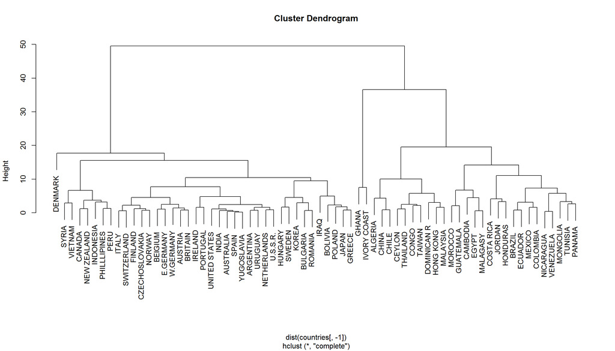

```r
plot(fit_hc)
```

剪枝可以控制输出类别个数或树高度

```r
group_k3 <- cutree(fit_hc,k=3)
group_k3
```

```
##        ALGERIA          CONGO          EGYPT          GHANA    IVORY COAST
##              1              1              1              2              2
##       MALAGASY        MOROCCO        TUNISIA       CAMBODIA         CEYLON
##              1              1              1              1              1
##          CHINA         TAIWAN      HONG KONG          INDIA      INDONESIA
##              1              1              1              3              3
##           IRAQ          JAPAN         JORDAN          KOREA       MALAYSIA
##              3              3              1              3              1
##       MONGOLIA   PHILLLIPINES          SYRIA       THAILAND        VIETNAM
##              1              3              3              1              3
##         CANADA     COSTA RICA    DOMINICAN R      GUATEMALA       HONDURAS
##              3              1              1              1              1
##         MEXICO      NICARAGUA         PANAMA  UNITED STATES      ARGENTINA
##              1              1              1              3              3
##        BOLIVIA         BRAZIL          CHILE       COLOMBIA        ECUADOR
##              3              1              1              1              1
##           PERU        URUGUAY      VENEZUELA        AUSTRIA        BElGIUM
##              3              3              1              3              3
##        BRITAIN       BULGARIA CZECHOSLOVAKIA        DENMARK        FINLAND
##              3              3              3              3              3
##      E.GERMANY      W.GERMANY         GREECE        HUNGARY        IRELAND
##              3              3              3              3              3
##          ITALY    NETHERLANDS         NORWAY         POLAND       PORTUGAL
##              3              3              3              3              3
##        ROMANIA          SPAIN         SWEDEN    SWITZERLAND       U.S.S.R.
##              3              3              3              3              3
##     YUGOSLAVIA      AUSTRALIA    NEW ZEALAND
##              3              3              3
```

```r
table(group_k3)
```

```
## group_k3
##  1  2  3
## 27  2 39
```

```r
group_h18 <- cutree(fit_hc,h=18)
group_h18
```

```
##        ALGERIA          CONGO          EGYPT          GHANA    IVORY COAST
##              1              1              2              3              3
##       MALAGASY        MOROCCO        TUNISIA       CAMBODIA         CEYLON
##              2              2              2              2              1
##          CHINA         TAIWAN      HONG KONG          INDIA      INDONESIA
##              1              1              1              4              4
##           IRAQ          JAPAN         JORDAN          KOREA       MALAYSIA
##              4              4              2              4              1
##       MONGOLIA   PHILLLIPINES          SYRIA       THAILAND        VIETNAM
##              2              4              4              1              4
##         CANADA     COSTA RICA    DOMINICAN R      GUATEMALA       HONDURAS
##              4              2              1              2              2
##         MEXICO      NICARAGUA         PANAMA  UNITED STATES      ARGENTINA
##              2              2              2              4              4
##        BOLIVIA         BRAZIL          CHILE       COLOMBIA        ECUADOR
##              4              2              1              2              2
##           PERU        URUGUAY      VENEZUELA        AUSTRIA        BElGIUM
##              4              4              2              4              4
##        BRITAIN       BULGARIA CZECHOSLOVAKIA        DENMARK        FINLAND
##              4              4              4              4              4
##      E.GERMANY      W.GERMANY         GREECE        HUNGARY        IRELAND
##              4              4              4              4              4
##          ITALY    NETHERLANDS         NORWAY         POLAND       PORTUGAL
##              4              4              4              4              4
##        ROMANIA          SPAIN         SWEDEN    SWITZERLAND       U.S.S.R.
##              4              4              4              4              4
##     YUGOSLAVIA      AUSTRALIA    NEW ZEALAND
##              4              4              4
```

```r
table(group_h18)
```

```
## group_h18
##  1  2  3  4
## 10 17  2 39
```

```r
unique(group_k3)
```

```
## [1] 1 2 3
```

查看各类别样本

```r
sapply(unique(group_k3),function(g) countries$country[group_k3==g])
```

```
## [[1]]
##  [1] ALGERIA     CONGO       EGYPT       MALAGASY    MOROCCO
##  [6] TUNISIA     CAMBODIA    CEYLON      CHINA       TAIWAN
## [11] HONG KONG   JORDAN      MALAYSIA    MONGOLIA    THAILAND
## [16] COSTA RICA  DOMINICAN R GUATEMALA   HONDURAS    MEXICO
## [21] NICARAGUA   PANAMA      BRAZIL      CHILE       COLOMBIA
## [26] ECUADOR     VENEZUELA
## 69 Levels: ALGERIA ARGENTINA AUSTRALIA AUSTRIA BElGIUM BOLIVIA ... YUGOSLAVIA
##
## [[2]]
## [1] GHANA       IVORY COAST
## 69 Levels: ALGERIA ARGENTINA AUSTRALIA AUSTRIA BElGIUM BOLIVIA ... YUGOSLAVIA
##
## [[3]]
##  [1] INDIA          INDONESIA      IRAQ           JAPAN
##  [5] KOREA          PHILLLIPINES   SYRIA          VIETNAM
##  [9] CANADA         UNITED STATES  ARGENTINA      BOLIVIA
## [13] PERU           URUGUAY        AUSTRIA        BElGIUM
## [17] BRITAIN        BULGARIA       CZECHOSLOVAKIA DENMARK
## [21] FINLAND        E.GERMANY      W.GERMANY      GREECE
## [25] HUNGARY        IRELAND        ITALY          NETHERLANDS
## [29] NORWAY         POLAND         PORTUGAL       ROMANIA
## [33] SPAIN          SWEDEN         SWITZERLAND    U.S.S.R.
## [37] YUGOSLAVIA     AUSTRALIA      NEW ZEALAND
## 69 Levels: ALGERIA ARGENTINA AUSTRALIA AUSTRIA BElGIUM BOLIVIA ... YUGOSLAVIA
```

上述过程，通过cutree()的使用查看了指定类别数k或树高度h的聚类结果；

另外，还可以通过控制k和h来控制，使用rect.hclus()函数从系谱图中选择查看聚类结果

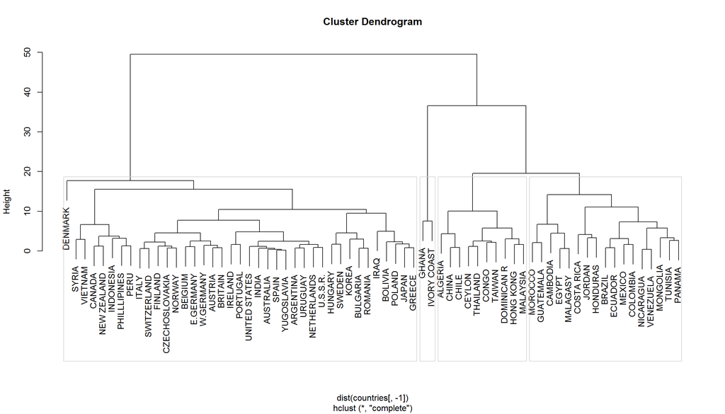

```r
plot(fit_hc)
rect.hclust(fit_hc,k=4,border="light grey")
```

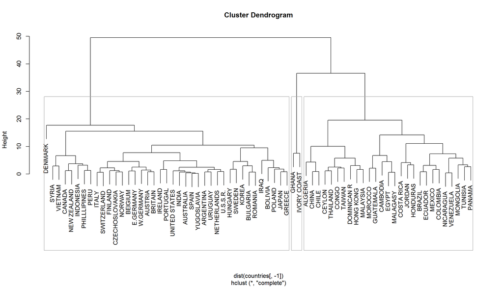

```r
plot(fit_hc)
rect.hclust(fit_hc,k=3,border="dark grey")
```

用深灰色框出7分类的第2类和第6类的聚类结果

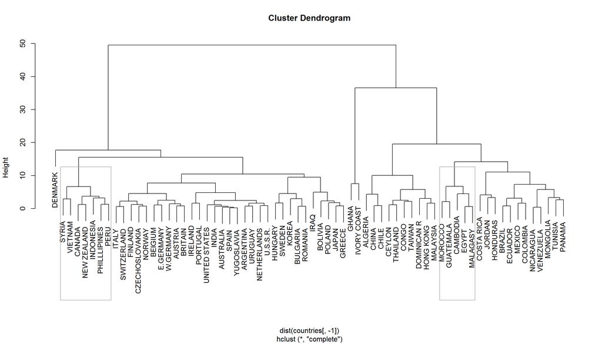

```r
plot(fit_hc)
rect.hclust(fit_hc,k=7,which=c(2,6),border="darkgrey")
```

### 7.3.5 期望最大化聚类

```r
fit_EM <- Mclust(countries[,-1])
summary(fit_EM)
```

```
## ----------------------------------------------------
## Gaussian finite mixture model fitted by EM algorithm
## ----------------------------------------------------
##
## Mclust EII (spherical, equal volume) model with 4 components:
##
##  log.likelihood  n df      BIC       ICL
##        -418.415 68 12 -887.464 -893.5937
##
## Clustering table:
##  1  2  3  4
##  2 13 17 36
```

根据BIC选择出的最佳模型类型为EII，最优类别数为4

```r
summary(fit_EM,parameters = T)
```

```
## ----------------------------------------------------
## Gaussian finite mixture model fitted by EM algorithm
## ----------------------------------------------------
##
## Mclust EII (spherical, equal volume) model with 4 components:
##
##  log.likelihood  n df      BIC       ICL
##        -418.415 68 12 -887.464 -893.5937
##
## Clustering table:
##  1  2  3  4
##  2 13 17 36
##
## Mixing probabilities:
##          1          2          3          4
## 0.02941271 0.18048749 0.25049059 0.53960920
##
## Means:
##           [,1]      [,2]     [,3]      [,4]
## birth 55.94969 33.550421 43.78269 19.721824
## death 29.34963  8.512713 12.08308  9.192534
##
## Variances:
## [,,1]
##          birth    death
## birth 10.10353  0.00000
## death  0.00000 10.10353
## [,,2]
##          birth    death
## birth 10.10353  0.00000
## death  0.00000 10.10353
## [,,3]
##          birth    death
## birth 10.10353  0.00000
## death  0.00000 10.10353
## [,,4]
##          birth    death
## birth 10.10353  0.00000
## death  0.00000 10.10353
```

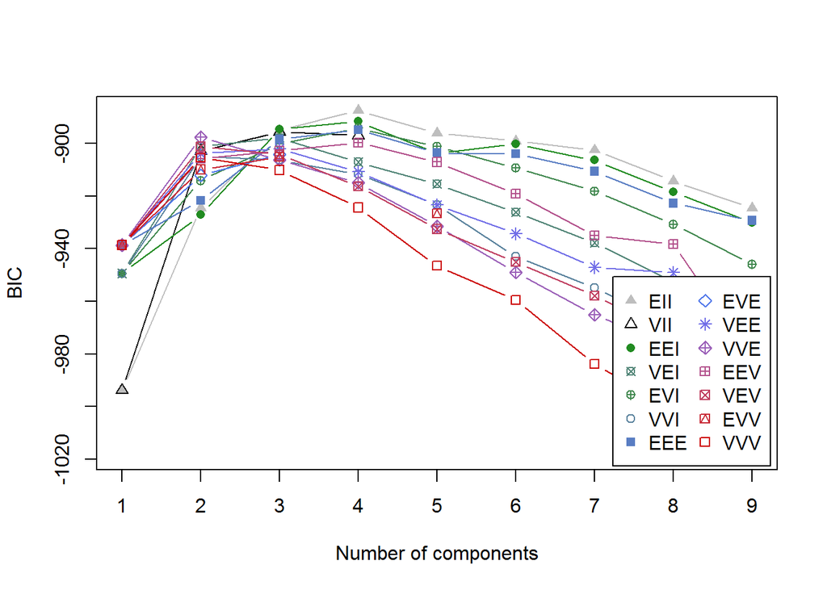

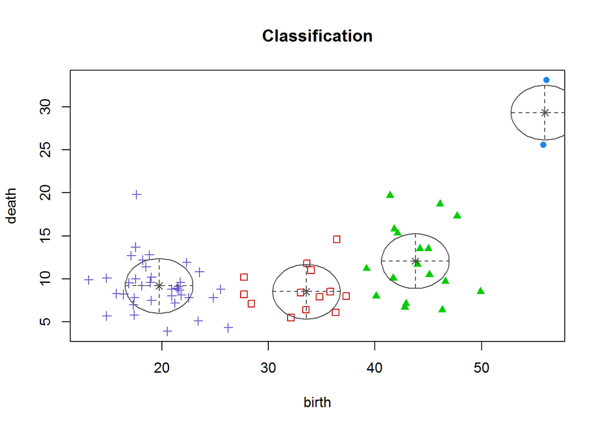

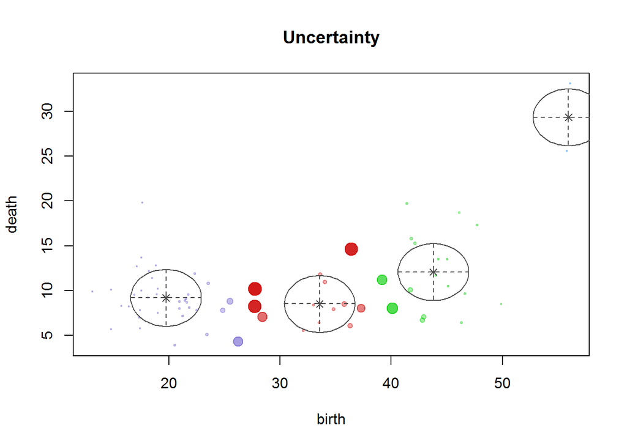

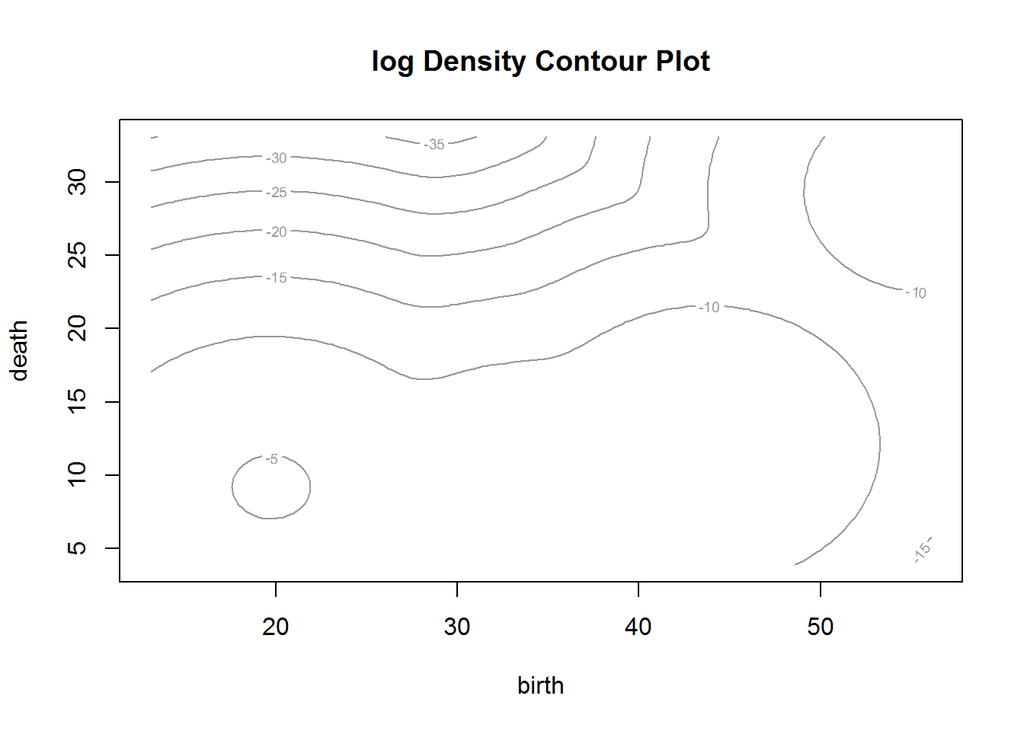

```r
plot(fit_EM)
```